# lab5_final

## Lab Assignment Five: Wide and Deep Networks

### Team members: Jinyu Du, Hessam Emami

### Business overview

Airline passenger satisfaction is unique to the airline industry and has key passenger experience measures such as ease of online booking, on-time arrival, boarding process, baggage handling, arrival delay, in-flight services, cleanness [1]. The hit of COVID-19 imposed more challenges on the airline industry and the post COVID-19 era airline passenger satisfaction will also hinge on different aspects such as cleaning/sanitization actions and safety, flexibility with changing schedules, and waving change and cancellation fees [2]. There are nine major airlines and some smaller carriers in the United States. The airline industry is highly competitive. Understanding passengers' satisfaction levels and its key indicators can help airline companies gauge their performance periodically and improve their competitive capabilities.

This lab project aims to build neural network models with different wide and deep network architures for binary-class passenger satisfaction classification. Other objectives of this lab include fine-tuning hyperparameters such as the size of the embedding matrix and layers of the deep network, comparing model performance, and visualizing results whenever necessary.

The models can predict airline passenger satisfaction based on airline customer survey data. The models should be deployed primarily for offline analysis because there is usually a turnaround time to collect data from surveys, and periodical and offline checks for passenger satisfaction should be sufficient.

### An overview of the dataset

The airline passenger satisfaction dataset was downloaded from Kaggle [3]. The data is collected from a customer satisfaction survey, and it is suitable for building classification models. This dataset includes 103904 entries and 24 attributes.

The dataset can be accessed from here:

[Airline Passenger Satisfaction](https://www.kaggle.com/teejmahal20/airline-passenger-satisfaction)

Dataset Author: [T J Klein](https://www.kaggle.com/teejmahal20)

#### Purpose of the data

The dataset is suitable for building classification models that predict airline passenger satisfaction. The original dataset has a target attribute named "satisfaction" with two categories: "Satisfaction", "neutral or dissatisfaction". In this lab, it will be used as the target variable for a binary classification problem. Standard scaler is used to normalize numerical and ordinal attributes in the dataset. The "id" attribute is removed from the dataset because it is not useful for building the classification model. Our team intends to build neural network models for binary-class prediction and apply our models for airline passenger satisfaction prediction.

#### Dataset decscription

The original dataset includes airline passenger satisfaction data. It contains six categorical attributes, four numerical attributes, and fourteen ordinal attributes. We treat all of the ordinal attributes as numerical attributes in our models. The attributes and their types are:

1. Categorical attributes: Id, Gender, Customer Type, Type of Travel, Class, and satisfaction
2. Numerical attributes: Age, Flight Distance, Departure Delay in Minutes, and Arrival Delay in Minutes
3. Ordinal attributes: Inflight wifi service, Departure/Arrival time convenient, Ease of Online booking, Gate location, Food and drink, Online boarding, Seat comfort, Inflight entertainment, On-board service, Legroom service, Baggage handling, Checkin service, Inflight service, and Cleanliness

The categorical attributes in the original dataset do not have many categories. We created two new categorical attributes using the numerical attributes 'Age' and 'Flight Distance'. Details for creating new categorical attributes can be found in later sections.

```python
import copy
from copy import deepcopy

import matplotlib
import matplotlib.pyplot as plt
%matplotlib inline

import missingno as mn

import numpy as np

import pandas as pd

from sklearn import metrics as mt
from sklearn.model_selection import train_test_split
from sklearn.preprocessing import LabelEncoder
from sklearn.preprocessing import StandardScaler

# the mcnemar test
from statsmodels.stats.contingency_tables import mcnemar

import tensorflow as tf
from tensorflow import keras
print(f"The version of keras is {keras.__version__}")
from tensorflow.keras.layers import Dense, Activation, Input
from tensorflow.keras.layers import Embedding, Flatten, Concatenate
# concatenate is different from Concatenate!
from tensorflow.keras.layers import concatenate
from tensorflow.keras.models import Model
from tensorflow.keras.utils import plot_model

import warnings
warnings.simplefilter('ignore', DeprecationWarning)
```

```
The version of keras is 2.4.0
```

```python
dataset_url = 'ds/train.csv'
df = pd.read_csv(dataset_url, index_col=0)

df.head()
```

|  | id | Gender | Customer Type | Age | Type of Travel | Class | Flight Distance | Inflight wifi service | Departure/Arrival time convenient | Ease of Online booking | ... | Inflight entertainment | On-board service | Leg room service | Baggage handling | Checkin service | Inflight service | Cleanliness | Departure Delay in Minutes | Arrival Delay in Minutes | satisfaction |
| --- | --- | --- | --- | --- | --- | --- | --- | --- | --- | --- | --- | --- | --- | --- | --- | --- | --- | --- | --- | --- | --- |
| 0 | 70172 | Male | Loyal Customer | 13 | Personal Travel | Eco Plus | 460 | 3 | 4 | 3 | ... | 5 | 4 | 3 | 4 | 4 | 5 | 5 | 25 | 18.0 | neutral or dissatisfied |
| 1 | 5047 | Male | disloyal Customer | 25 | Business travel | Business | 235 | 3 | 2 | 3 | ... | 1 | 1 | 5 | 3 | 1 | 4 | 1 | 1 | 6.0 | neutral or dissatisfied |
| 2 | 110028 | Female | Loyal Customer | 26 | Business travel | Business | 1142 | 2 | 2 | 2 | ... | 5 | 4 | 3 | 4 | 4 | 4 | 5 | 0 | 0.0 | satisfied |
| 3 | 24026 | Female | Loyal Customer | 25 | Business travel | Business | 562 | 2 | 5 | 5 | ... | 2 | 2 | 5 | 3 | 1 | 4 | 2 | 11 | 9.0 | neutral or dissatisfied |
| 4 | 119299 | Male | Loyal Customer | 61 | Business travel | Business | 214 | 3 | 3 | 3 | ... | 3 | 3 | 4 | 4 | 3 | 3 | 3 | 0 | 0.0 | satisfied |

5 rows × 24 columns

```python
print(df.info())
print()
print(f"The total number of observations in the dateset is {len(df)}.")
print()
print(f"The shape of the dateset is {df.shape}.")
```

```
<class 'pandas.core.frame.DataFrame'>
Int64Index: 103904 entries, 0 to 103903
Data columns (total 24 columns):
 #   Column                             Non-Null Count   Dtype
---  ------                             --------------   -----
 0   id                                 103904 non-null  int64
 1   Gender                             103904 non-null  object
 2   Customer Type                      103904 non-null  object
 3   Age                                103904 non-null  int64
 4   Type of Travel                     103904 non-null  object
 5   Class                              103904 non-null  object
 6   Flight Distance                    103904 non-null  int64
 7   Inflight wifi service              103904 non-null  int64
 8   Departure/Arrival time convenient  103904 non-null  int64
 9   Ease of Online booking             103904 non-null  int64
 10  Gate location                      103904 non-null  int64
 11  Food and drink                     103904 non-null  int64
 12  Online boarding                    103904 non-null  int64
 13  Seat comfort                       103904 non-null  int64
 14  Inflight entertainment             103904 non-null  int64
 15  On-board service                   103904 non-null  int64
 16  Leg room service                   103904 non-null  int64
 17  Baggage handling                   103904 non-null  int64
 18  Checkin service                    103904 non-null  int64
 19  Inflight service                   103904 non-null  int64
 20  Cleanliness                        103904 non-null  int64
 21  Departure Delay in Minutes         103904 non-null  int64
 22  Arrival Delay in Minutes           103594 non-null  float64
 23  satisfaction                       103904 non-null  object
dtypes: float64(1), int64(18), object(5)
memory usage: 19.8+ MB
None

The total number of observations in the dateset is 103904.

The shape of the dateset is (103904, 24).
```

```python
# show the number of missing values for each attribute
total_missing_values = df.isnull().sum().sort_values(ascending = False)
print("The number of missing values in each attribute: ")
total_missing_values
```

```
The number of missing values in each attribute:
```

```
Arrival Delay in Minutes             310
id                                     0
Gender                                 0
Departure Delay in Minutes             0
Cleanliness                            0
Inflight service                       0
Checkin service                        0
Baggage handling                       0
Leg room service                       0
On-board service                       0
Inflight entertainment                 0
Seat comfort                           0
Online boarding                        0
Food and drink                         0
Gate location                          0
Ease of Online booking                 0
Departure/Arrival time convenient      0
Inflight wifi service                  0
Flight Distance                        0
Class                                  0
Type of Travel                         0
Age                                    0
Customer Type                          0
satisfaction                           0
dtype: int64
```

```python
#Find abnormal values in dataset
def validate_data(df):
    valid_attr = np.array([])
    valid_attr = np.append(valid_attr,
                           {'Gender' : {'Male', 'Female'} == set(df['Gender'].unique())})
    valid_attr = np.append(valid_attr,
                           {'Customer Type' : {'Loyal Customer', 'disloyal Customer'} == set(df['Customer Type'].unique())})
    valid_attr = np.append(valid_attr,
                           {'Type of Travel' : {'Personal Travel', 'Business travel'} == set(df['Type of Travel'].unique())})
    valid_attr = np.append(valid_attr,
                           {'Class' : {'Eco', 'Eco Plus', 'Business'} == set(df['Class'].unique())})
    valid_attr = np.append(valid_attr,
                           {'satisfaction' :  {'neutral or dissatisfied', 'satisfied'} == set(df['satisfaction'].unique())})
    return valid_attr

print(validate_data(df))
print()
print(df.info())
print()
print("Number of duplicated rows in the data set is: {}".format(len(df) - len(df.drop_duplicates())))
```

```
[{'Gender': True} {'Customer Type': True} {'Type of Travel': True}
 {'Class': True} {'satisfaction': True}]

<class 'pandas.core.frame.DataFrame'>
Int64Index: 103904 entries, 0 to 103903
Data columns (total 24 columns):
 #   Column                             Non-Null Count   Dtype
---  ------                             --------------   -----
 0   id                                 103904 non-null  int64
 1   Gender                             103904 non-null  object
 2   Customer Type                      103904 non-null  object
 3   Age                                103904 non-null  int64
 4   Type of Travel                     103904 non-null  object
 5   Class                              103904 non-null  object
 6   Flight Distance                    103904 non-null  int64
 7   Inflight wifi service              103904 non-null  int64
 8   Departure/Arrival time convenient  103904 non-null  int64
 9   Ease of Online booking             103904 non-null  int64
 10  Gate location                      103904 non-null  int64
 11  Food and drink                     103904 non-null  int64
 12  Online boarding                    103904 non-null  int64
 13  Seat comfort                       103904 non-null  int64
 14  Inflight entertainment             103904 non-null  int64
 15  On-board service                   103904 non-null  int64
 16  Leg room service                   103904 non-null  int64
 17  Baggage handling                   103904 non-null  int64
 18  Checkin service                    103904 non-null  int64
 19  Inflight service                   103904 non-null  int64
 20  Cleanliness                        103904 non-null  int64
 21  Departure Delay in Minutes         103904 non-null  int64
 22  Arrival Delay in Minutes           103594 non-null  float64
 23  satisfaction                       103904 non-null  object
dtypes: float64(1), int64(18), object(5)
memory usage: 19.8+ MB
None

Number of duplicated rows in the data set is: 0
```

```python
df_imputed = copy.deepcopy(df)

df_imputed.dropna(inplace=True)

for col in ['id' ] :
        del df_imputed[col]

df_imputed.reset_index()
# replace space,-,/ in column names with underscore. This is needed for Keras!
df_imputed.columns = df_imputed.columns.str.replace(' ', '_').str.replace('-', '_').str.replace('/', '_')
```

### Converting 'Flight_Distance' and 'Age' to categorical attributes

The original dataset has two numerical attributes: "Flight_Distance" and "Age." We convert these two attributes to categorical attributes. The primary reason behind this change is that the categorical attributes in the original dataset do not have many categories, and we need more categorical attributes with four or more categories to create wider branches for the wide and deep network. Moreover, doing this will make the embedding matrix multi-dimensional, and it is easier and more meaningful to visualize the embedding weights in the exceptional work section.

The following are the new attributes and their values [5]:

1) Age_c: (0-12] (child), (12-19] (teen), (19-30] (young), (30, Inf)(adult)  
2) Flight_Distance_c: (0-600] mile (short-haul), (600-2000] (medium-haul), (2000-3500] long-haul, ultra-long-haul (3500,Inf)

```python
def Age_convertor(df):
    Age_c = []
    for a in df['Age']:
        if a <= 12 :
            Age_c.append('child')
        if a > 12 and a <=19 :
            Age_c.append('teen')
        if a > 19 and a <= 30 :
            Age_c.append('young')
        if a > 30 :
            Age_c.append('adult')

    return Age_c

def Flight_Distance_convertor(df):
    Flight_Distance_c = []
    for f in df['Flight_Distance']:
        if f <= 600 :
            Flight_Distance_c.append('short_haul')
        if f > 600 and f <= 2000 :
            Flight_Distance_c.append('medium_haul')
        if f > 2000 and f <=3500 :
            Flight_Distance_c.append('long_haul')
        if f > 3500 :
            Flight_Distance_c.append('ultra_long_haul')

    return Flight_Distance_c

df_imputed['Flight_Distance_c'] = Flight_Distance_convertor(df_imputed)
df_imputed['Age_c'] = Age_convertor(df_imputed)
```

```python
# check again to see if there are any missing values
for col in ['Age', 'Flight_Distance'] :
        del df_imputed[col]

total_missing_values = df_imputed.isnull().sum().sort_values(ascending = False)
print("After data pre-processing, the number of missing values in each attribute: ")
total_missing_values
```

```
After data pre-processing, the number of missing values in each attribute:
```

```
Gender                               0
On_board_service                     0
Flight_Distance_c                    0
satisfaction                         0
Arrival_Delay_in_Minutes             0
Departure_Delay_in_Minutes           0
Cleanliness                          0
Inflight_service                     0
Checkin_service                      0
Baggage_handling                     0
Leg_room_service                     0
Inflight_entertainment               0
Customer_Type                        0
Seat_comfort                         0
Online_boarding                      0
Food_and_drink                       0
Gate_location                        0
Ease_of_Online_booking               0
Departure_Arrival_time_convenient    0
Inflight_wifi_service                0
Class                                0
Type_of_Travel                       0
Age_c                                0
dtype: int64
```

```python
df_imputed.info()
```

```
<class 'pandas.core.frame.DataFrame'>
Int64Index: 103594 entries, 0 to 103903
Data columns (total 23 columns):
 #   Column                             Non-Null Count   Dtype
---  ------                             --------------   -----
 0   Gender                             103594 non-null  object
 1   Customer_Type                      103594 non-null  object
 2   Type_of_Travel                     103594 non-null  object
 3   Class                              103594 non-null  object
 4   Inflight_wifi_service              103594 non-null  int64
 5   Departure_Arrival_time_convenient  103594 non-null  int64
 6   Ease_of_Online_booking             103594 non-null  int64
 7   Gate_location                      103594 non-null  int64
 8   Food_and_drink                     103594 non-null  int64
 9   Online_boarding                    103594 non-null  int64
 10  Seat_comfort                       103594 non-null  int64
 11  Inflight_entertainment             103594 non-null  int64
 12  On_board_service                   103594 non-null  int64
 13  Leg_room_service                   103594 non-null  int64
 14  Baggage_handling                   103594 non-null  int64
 15  Checkin_service                    103594 non-null  int64
 16  Inflight_service                   103594 non-null  int64
 17  Cleanliness                        103594 non-null  int64
 18  Departure_Delay_in_Minutes         103594 non-null  int64
 19  Arrival_Delay_in_Minutes           103594 non-null  float64
 20  satisfaction                       103594 non-null  object
 21  Flight_Distance_c                  103594 non-null  object
 22  Age_c                              103594 non-null  object
dtypes: float64(1), int64(15), object(7)
memory usage: 19.0+ MB
```

```python
print(f'''The shape of the dateset is {df_imputed.shape} after removing
redundant attributes and rows with missing values.''')
```

```
The shape of the dateset is (103594, 23) after removing
redundant attributes and rows with missing values.
```

The dataset we chose was easy to clean up. We removed the attribute named 'id' and rows with missing values. We created two new categorical attributes using the numerical attributes 'Age' and 'Flight Distance'. The final dataset that is used for building neural network classification models has 103594 observations and 23 attributes.

### Identifying groups of features for creating cross-product features

There are seven categorical attributes in the dataset, and one of them 'satisfaction' will be used as the target. This model predicts airline passenger satisfaction based on airline customer survey data. Satisfaction may depend on all attributes in this dataset, but we could create some rule-based logic on existing categorical features. For example, longer flight distances could negatively impact satisfaction. It can affect the prediction model, but we know passengers in business class are more comfortable than economic class. Therefore the predication such as {Flight_Distance_c: long_haul, Class: Business, satisfaction: neutral or dissatisfied} can have a high probability but based on the rules, and what can be memorized and query, {Flight_Distance_c: long_haul, Class: Business, satisfaction: satisfied} could be more accurate. We can implement similar rules in neural networks by utilizing wide branches. Attributes that are related to each other can be crossed as new groups. By applying the above logic, we suggest the following categories as cross-product features:

**'Gender', 'Customer_Type', 'Age_c':** Loyal customers that fall into different gender and age categories may show a different reaction to issues that happen during travel than disloyal customers.

**'Gender', 'Customer_Type', 'Type_of_Travel', 'Flight_Distance_c':** The passenger satisfaction may depend on Gender, Customer_Type, the purpos of the travel (type of travel) , and Flight_Distance_c.

**'Gender', 'Customer_Type', 'Class'** Type of travel (Personal or business) can change the passengers' view on the quality of the service, which can also be related to gender and flight class.

To implement different model, we create the following cross-features for some of the model's wide branch:

**'Gender', 'Class', 'Age_c', 'Flight_Distance_c':** Long flights can be tolerated better in business class than economy class, and younger passengers could enjoy long-haul flights more than older ones based on their age.

**'Gender', 'Type_of_Travel', 'Age_c':** Older passengers are most likely to travel for business reasons, but the male percentage could be higher than female.

### Metric for evaluating model performace

The goal of our model is to generate the most accurate classification for airline passenger satisfaction. We live in an era that many passenger airlines struggle to maintain their businesses, and the COVID-19 pandemic made this even more challenging. Airlines experience a sharp decline in passenger numbers, and Cargo is becoming more important than passenger travels in airlines. To mitigate the risk of bankruptcy and maintain its prosperity, airlines have to stay competitive to use the prediction for scoring purposes such as employee performance review, business plan effectiveness, and risk management.

Prediction accuracy for the two categories of the target attribute is the primary measure of success. In other words, we aim for the most accurate classification for airline passenger satisfaction. Filipe, Tonetto, et al. applied a text mining approach to explore airline customer satisfaction using online customer reviews and achieved an accuracy of 79.95%. There is only a 13 percent difference in binary values of satisfaction attributes in our dataset, neither of the binary classes has a remarkable impact on the accuracy alone. For example, if the target attribute is very imbalanced, such as 90% of customers are satisfied and 10% are neutral/dissatisfied, the model can achieve 90% accuracy even if its prediction for neutral/dissatisfied is entirely wrong. For applying our wide and deep network models to classify passenger satisfaction, we consider accuracy 80% or above acceptable [4].

Prediction errors are unavoidable with a high-dimensional model. In this context, mistakenly categorizing unsatisfied customers as satisfied is more detrimental than recognizing satisfied customers as unsatisfied. Therefore, a secondary metric for performance evaluation should be precision. Airlines intend to stay competitive. Thus, higher precision is preferred for models with comparable accuracy because these models produce relatively fewer false-positive predictions.

We evaluate models using the receiver operating characteristic and area under the curve. We also use the McNeymar statistical tests to compare the model performance.

### Training and testing split

```python
target_counts = df_imputed['satisfaction'].value_counts()

print('The total number of satisfied customers is: ', target_counts[1])
print()
print('The total number of disloyal customers and neutral or dissatisfied customers is: ', target_counts[0])
print()
ratio_target = (target_counts[0]) / (target_counts[1])
print(f'''The total number of  disloyal customers and neutral or dissatisfied customers
is {ratio_target:.3f} times of the total number of satisfied customers.''')
```

```
The total number of satisfied customers is:  44897

The total number of disloyal customers and neutral or dissatisfied customers is:  58697

The total number of  disloyal customers and neutral or dissatisfied customers
is 1.307 times of the total number of satisfied customers.
```

The dataset is shuffled and randomly divided into 80 percent for training and 20 percent for testing based on a stratified train-test split. We believe the 80/20 split is sufficient because our dataset is large, with 103594 observations. According to what we learned in Dr. Larson's class, a dataset with more than 50000 observations can be considered large, and there is no practical advantage in performing cross-validation or nested cross-validation for a large dataset. Moreover, observations are independent of each other, and there is no spatial or temporal information in the dataset. Finally, the number of instances in each target class is relatively close, and there are no obvious class imbalance issues. Therefore, we will use a simple stratified shuffle split for our dataset for model validation purposes.

```python
y_raw = df_imputed['satisfaction']
df_tmp = copy.deepcopy(df_imputed)
del df_tmp['satisfaction']
X_raw = df_tmp

X_train_raw, X_test_raw, y_train_raw, y_test_raw = train_test_split(X_raw,y_raw,test_size = 0.2,
                                                                    stratify=y_raw,
                                                                    random_state=7324,
                                                                    shuffle=True)
# create raw train and test dataset by concatenating x and y
df_train_orig = pd.concat([X_train_raw, y_train_raw], axis=1)
df_test_orig = pd.concat([X_test_raw, y_test_raw], axis=1)

# X_train_raw = X_train_raw.to_numpy()
# X_test_raw = X_test_raw.to_numpy()
# y_train_raw = y_train_raw.to_numpy()
# y_test_raw = y_test_raw.to_numpy()

print()
print(f"The shape of the training dateset is {df_train_orig.shape}.")
print()
print(f"The shape of the testing dateset is {df_test_orig.shape}.")
```

```
The shape of the training dateset is (82875, 23).

The shape of the testing dateset is (20719, 23).
```

```python
df_train = deepcopy(df_train_orig)
df_train = df_train.reset_index(drop=True)
# df_train.head()

df_test = deepcopy(df_test_orig)
df_test = df_test.reset_index(drop=True)
# df_test.head()
```

### Converting categorical attributes to be integer valued

```python
# define objects that can encode each variable as integer
encoders = dict()
categorical_headers = ['Gender',
                       'Customer_Type',
                       'Type_of_Travel',
                       'Class',
                       'Age_c',
                       'Flight_Distance_c']

for col in categorical_headers+['satisfaction']:
    df_train[col] = df_train[col].str.strip()
    df_test[col] = df_test[col].str.strip()
    if col=="satisfaction": # target attribute
        tmp = LabelEncoder()
        df_train[col] = tmp.fit_transform(df_train[col])
        df_test[col] = tmp.transform(df_test[col])
    else:
        # integer encoded variables
        encoders[col] = LabelEncoder() # save the encoder
        df_train[col+'_int'] = encoders[col].fit_transform(df_train[col])
        df_test[col+'_int'] = encoders[col].transform(df_test[col])
```

### Normalizing numeric attributes

```python
#Arrival Delay is in Minutes , Departure Delay is in Minutes
numeric_headers = ['Inflight_wifi_service',
                   'Departure_Arrival_time_convenient',
                   'Ease_of_Online_booking',
                   'Gate_location',
                   'Food_and_drink',
                   'Online_boarding',
                   'Seat_comfort',
                   'Inflight_entertainment',
                   'On_board_service',
                   'Leg_room_service',
                   'Baggage_handling',
                   'Checkin_service',
                   'Inflight_service',
                   'Cleanliness',
                   'Departure_Delay_in_Minutes',
                   'Arrival_Delay_in_Minutes']

for col in numeric_headers:
    df_train[col] = df_train[col].astype(np.float)
    df_test[col] = df_test[col].astype(np.float)

    ss = StandardScaler()
    df_train[col] = ss.fit_transform(df_train[col].values.reshape(-1, 1))
    df_test[col] = ss.transform(df_test[col].values.reshape(-1, 1))

print("The first 5 rows of the training dataset:")
df_train.head()
```

```
The first 5 rows of the training dataset:
```

|  | Gender | Customer_Type | Type_of_Travel | Class | Inflight_wifi_service | Departure_Arrival_time_convenient | Ease_of_Online_booking | Gate_location | Food_and_drink | Online_boarding | ... | Arrival_Delay_in_Minutes | Flight_Distance_c | Age_c | satisfaction | Gender_int | Customer_Type_int | Type_of_Travel_int | Class_int | Age_c_int | Flight_Distance_c_int |
| --- | --- | --- | --- | --- | --- | --- | --- | --- | --- | --- | --- | --- | --- | --- | --- | --- | --- | --- | --- | --- | --- |
| 0 | Male | Loyal Customer | Business travel | Business | -0.553193 | -0.696357 | -0.543873 | -0.767211 | -0.904193 | -0.186848 | ... | -0.391660 | long_haul | adult | 1 | 1 | 0 | 0 | 0 | 0 | 0 |
| 1 | Female | Loyal Customer | Personal Travel | Eco Plus | -1.307063 | -0.696357 | -1.259608 | 0.016309 | -0.904193 | -1.670590 | ... | 0.200149 | medium_haul | young | 0 | 0 | 0 | 1 | 2 | 3 | 1 |
| 2 | Female | Loyal Customer | Personal Travel | Eco | 0.200677 | -0.039876 | -0.543873 | 0.799828 | 1.355221 | -0.928719 | ... | -0.391660 | long_haul | adult | 0 | 0 | 0 | 1 | 1 | 0 | 0 |
| 3 | Male | Loyal Customer | Business travel | Eco | 1.708418 | -0.039876 | 0.171863 | 0.016309 | 1.355221 | 0.555022 | ... | -0.391660 | short_haul | adult | 1 | 1 | 0 | 0 | 1 | 0 | 2 |
| 4 | Male | Loyal Customer | Business travel | Business | 1.708418 | 1.273085 | 1.603334 | 1.583347 | -0.904193 | -0.186848 | ... | -0.391660 | medium_haul | young | 1 | 1 | 0 | 0 | 0 | 3 | 1 |

5 rows × 29 columns

```python
print("The first 5 rows of the testing dataset:")
df_test.head()
```

```
The first 5 rows of the testing dataset:
```

|  | Gender | Customer_Type | Type_of_Travel | Class | Inflight_wifi_service | Departure_Arrival_time_convenient | Ease_of_Online_booking | Gate_location | Food_and_drink | Online_boarding | ... | Arrival_Delay_in_Minutes | Flight_Distance_c | Age_c | satisfaction | Gender_int | Customer_Type_int | Type_of_Travel_int | Class_int | Age_c_int | Flight_Distance_c_int |
| --- | --- | --- | --- | --- | --- | --- | --- | --- | --- | --- | --- | --- | --- | --- | --- | --- | --- | --- | --- | --- | --- |
| 0 | Male | Loyal Customer | Business travel | Business | 0.954548 | 0.616605 | 0.887598 | 0.799828 | -0.151055 | 0.555022 | ... | -0.391660 | medium_haul | adult | 1 | 1 | 0 | 0 | 0 | 0 | 1 |
| 1 | Female | Loyal Customer | Business travel | Business | -0.553193 | -0.696357 | -0.543873 | -0.767211 | 1.355221 | 1.296893 | ... | -0.031428 | medium_haul | young | 1 | 0 | 0 | 0 | 0 | 3 | 1 |
| 2 | Female | Loyal Customer | Business travel | Business | 1.708418 | 1.273085 | 1.603334 | 1.583347 | 1.355221 | -0.186848 | ... | -0.391660 | medium_haul | adult | 1 | 0 | 0 | 0 | 0 | 0 | 1 |
| 3 | Male | disloyal Customer | Business travel | Business | 0.200677 | -0.039876 | 0.171863 | 0.016309 | -1.657331 | -0.186848 | ... | 0.097226 | short_haul | adult | 0 | 1 | 1 | 0 | 0 | 0 | 2 |
| 4 | Female | disloyal Customer | Business travel | Eco | -0.553193 | -0.696357 | -0.543873 | 0.799828 | 1.355221 | -0.928719 | ... | -0.391660 | medium_haul | child | 0 | 0 | 1 | 0 | 1 | 1 | 1 |

5 rows × 29 columns

### Model 1: the first wide and deep neural network model

Model 1 is the first wide and deep neural network model we created. The wide branch was created using the crossed categorical features from [['Gender', 'Customer_Type', 'Age_c'], ['Gender', 'Customer_Type', 'Type_of_Travel', 'Flight_Distance_c'], ['Gender', 'Customer_Type', 'Class']] and then let it go through an embedding layer. The deep branch was created by concatenating the embedded categorical features and the numerical features and then letting it went through three dense layers with 50, 25, 10 neurons and relu activation function. We use floor($\sqrt{N}$) to determine the size of the feature embedding layers. Finally, both the wide and deep branches were concatenated together and passed through one dense layer with sigmoid activation function to get the prediction.

```python
categorical_headers_ints = [x+'_int' for x in categorical_headers]
y_train = df_train['satisfaction']
y_test = df_test['satisfaction']

cross_columns = [['Gender', 'Customer_Type', 'Age_c'],
                 ['Gender', 'Customer_Type', 'Type_of_Travel', 'Flight_Distance_c'],
                 ['Gender', 'Customer_Type', 'Class']]

# cross each set of columns in the list above
cross_col_df_names = []
for cols_list in cross_columns:
    # encode as ints for the embedding
    enc = LabelEncoder()

    # 1. create crossed labels by join operation
    X_crossed_train = df_train[cols_list].apply(lambda x: '_'.join(x), axis=1)
    X_crossed_test = df_test[cols_list].apply(lambda x: '_'.join(x), axis=1)

    # get a nice name for this new crossed column
    cross_col_name = '_'.join(cols_list)

    # 2. encode as integers
    enc.fit(np.hstack((X_crossed_train.to_numpy(),  X_crossed_test.to_numpy())))

    # 3. Save into dataframe with new name
    df_train[cross_col_name] = enc.transform(X_crossed_train)
    df_test[cross_col_name] = enc.transform(X_crossed_test)

    # keep track of the new names of the crossed columns
    cross_col_df_names.append(cross_col_name)
# get crossed columns
X_train_crossed = df_train[cross_col_df_names].to_numpy()
X_test_crossed = df_test[cross_col_df_names].to_numpy()

# save categorical features
X_train_cat = df_train[categorical_headers_ints].to_numpy()
X_test_cat = df_test[categorical_headers_ints].to_numpy()

# and save off the numeric features
X_train_num =  df_train[numeric_headers].to_numpy()
X_test_num = df_test[numeric_headers].to_numpy()


# we need to create separate lists for each branch
crossed_outputs = []

# CROSSED DATA INPUT
input_crossed = Input(shape=(X_train_crossed.shape[1],), dtype='int64', name='wide_inputs')
for idx,col in enumerate(cross_col_df_names):

    # track what the maximum integer value will be for this variable
    # which is the same as the number of categories
    N = max(df_train[col].max(),df_test[col].max())+1


    # this line of code does this: input_branch[:,idx]
    x = tf.gather(input_crossed, idx, axis=1)

    # now use an embedding to deal with integers as if they were one hot encoded
    x = Embedding(input_dim=N,
                  output_dim=int(np.sqrt(N)),
                  input_length=1, name=col+'_embed')(x)

    # save these outputs to concatenate later
    crossed_outputs.append(x)


# now concatenate the outputs and add a fully connected layer
wide_branch = concatenate(crossed_outputs, name='wide_concat')

# reset this input branch
all_deep_branch_outputs = []

# CATEGORICAL DATA INPUT
input_cat = Input(shape=(X_train_cat.shape[1],), dtype='int64', name='categorical_input')
for idx,col in enumerate(categorical_headers_ints):

    # track what the maximum integer value will be for this variable
    # which is the same as the number of categories
    N = max(df_train[col].max(),df_test[col].max())+1

    # this line of code does this: input_branch[:,idx]
    x = tf.gather(input_cat, idx, axis=1)

    # now use an embedding to deal with integers as if they were one hot encoded
    x = Embedding(input_dim=N,
                  output_dim=int(np.sqrt(N)),
                  input_length=1, name=col+'_embed')(x)

    # save these outputs to concatenate later
    all_deep_branch_outputs.append(x)

# NUMERIC DATA INPUT
# create dense input branch for numeric
input_num = Input(shape=(X_train_num.shape[1],), name='numeric')
x_dense = Dense(units=15, activation='relu',name='num_1')(input_num)

all_deep_branch_outputs.append(x_dense)


# merge the deep branches together
deep_branch = concatenate(all_deep_branch_outputs,name='concat_embeds')
deep_branch = Dense(units=50,activation='relu', name='deep1')(deep_branch)
deep_branch = Dense(units=25,activation='relu', name='deep2')(deep_branch)
deep_branch = Dense(units=10,activation='relu', name='deep3')(deep_branch)

# merge the deep and wide branch
final_branch = concatenate([wide_branch, deep_branch],
                           name='concat_deep_wide')
final_branch = Dense(units=1,activation='sigmoid',
                     name='combined')(final_branch)

model = Model(inputs=[input_crossed,input_cat,input_num],
              outputs=final_branch)
```

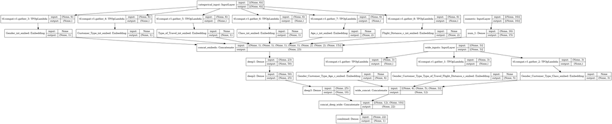

```python
plot_model(
    model, to_file='model.png', show_shapes=True, show_layer_names=True,
    rankdir='TB', expand_nested=False, dpi=96
)
# rankdir='LR'
# model.summary()
```

```python
%%time
model.compile(optimizer='adagrad',
              loss='mean_squared_error',
              metrics=['accuracy'])

# lets also add the history variable to see how we are doing
# and lets add a validation set to keep track of our progress
history = model.fit([X_train_crossed,X_train_cat,X_train_num],
                    y_train,
                    epochs=150,
                    batch_size=32,
                    verbose=1,
                    validation_data = ([X_test_crossed,X_test_cat,X_test_num],y_test))
```

```
CPU times: user 17min 8s, sys: 8min 26s, total: 25min 35s
Wall time: 7min 6s
```

```python
yhat = np.round(model.predict([X_test_crossed,X_test_cat,X_test_num]))
print(mt.confusion_matrix(y_test,yhat))
print(mt.classification_report(y_test,yhat))
```

```
[[11101   639]
 [  866  8113]]
              precision    recall  f1-score   support

           0       0.93      0.95      0.94     11740
           1       0.93      0.90      0.92      8979

    accuracy                           0.93     20719
   macro avg       0.93      0.92      0.93     20719
weighted avg       0.93      0.93      0.93     20719
```

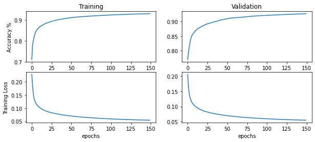

```python
from matplotlib import pyplot as plt

%matplotlib inline

plt.figure(figsize=(10,4))
plt.subplot(2,2,1)
plt.plot(history.history['accuracy'])

plt.ylabel('Accuracy %')
plt.title('Training')
plt.subplot(2,2,2)
plt.plot(history.history['val_accuracy'])
plt.title('Validation')

plt.subplot(2,2,3)
plt.plot(history.history['loss'])
plt.ylabel('Training Loss')
plt.xlabel('epochs')

plt.subplot(2,2,4)
plt.plot(history.history['val_loss'])
plt.xlabel('epochs')
```

### Model 2: the second wide and deep model

Model 2 is the second wide and deep neural network model we created. It is modified based on model 1. The major difference between model 2 and model 1 is that the wide branch of model 2 was wider than that from model 1 and it was created using the crossed categorical features from [['Gender', 'Customer_Type','Age_c'], ['Gender', 'Customer_Type', 'Type_of_Travel', 'Flight_Distance_c'], ['Gender', 'Class', 'Age_c', 'Flight_Distance_c'], ['Gender', 'Type_of_Travel', 'Age_c']] and then let it go through an embedding layer. We think 'Gender', 'Age_c', and 'Flight_Distance_c' critical for customer satisfaction. The deep branch of model 2 is the same as that from model 1. Finally, both the wide and deep branches were concatenated together and passed through one dense layer with a sigmoid activation function to get the prediction.

```python
categorical_headers_ints = [x+'_int' for x in categorical_headers]
y_train = df_train['satisfaction']
y_test = df_test['satisfaction']

cross_columns = [['Gender', 'Customer_Type','Age_c'],
                 ['Gender', 'Customer_Type', 'Type_of_Travel', 'Flight_Distance_c'],
                 ['Gender',  'Class', 'Age_c', 'Flight_Distance_c'],
                 ['Gender', 'Type_of_Travel', 'Age_c']]

# cross each set of columns in the list above
cross_col_df_names = []
for cols_list in cross_columns:
    # encode as ints for the embedding
    enc = LabelEncoder()

    # 1. create crossed labels by join operation
    X_crossed_train = df_train[cols_list].apply(lambda x: '_'.join(x), axis=1)
    X_crossed_test = df_test[cols_list].apply(lambda x: '_'.join(x), axis=1)

    # get a nice name for this new crossed column
    cross_col_name = '_'.join(cols_list)

    # 2. encode as integers
    enc.fit(np.hstack((X_crossed_train.to_numpy(),  X_crossed_test.to_numpy())))

    # 3. Save into dataframe with new name
    df_train[cross_col_name] = enc.transform(X_crossed_train)
    df_test[cross_col_name] = enc.transform(X_crossed_test)

    # keep track of the new names of the crossed columns
    cross_col_df_names.append(cross_col_name)
# get crossed columns
X_train_crossed = df_train[cross_col_df_names].to_numpy()
X_test_crossed = df_test[cross_col_df_names].to_numpy()

# save categorical features
X_train_cat = df_train[categorical_headers_ints].to_numpy()
X_test_cat = df_test[categorical_headers_ints].to_numpy()

# and save off the numeric features
X_train_num =  df_train[numeric_headers].to_numpy()
X_test_num = df_test[numeric_headers].to_numpy()


# we need to create separate lists for each branch
crossed_outputs = []

# CROSSED DATA INPUT
input_crossed = Input(shape=(X_train_crossed.shape[1],), dtype='int64', name='wide_inputs')
for idx,col in enumerate(cross_col_df_names):

    # track what the maximum integer value will be for this variable
    # which is the same as the number of categories
    N = max(df_train[col].max(),df_test[col].max())+1


    # this line of code does this: input_branch[:,idx]
    x = tf.gather(input_crossed, idx, axis=1)

    # now use an embedding to deal with integers as if they were one hot encoded
    x = Embedding(input_dim=N,
                  output_dim=int(np.sqrt(N)),
                  input_length=1, name=col+'_embed')(x)

    # save these outputs to concatenate later
    crossed_outputs.append(x)


# now concatenate the outputs and add a fully connected layer
wide_branch = concatenate(crossed_outputs, name='wide_concat')

# reset this input branch
all_deep_branch_outputs = []

# CATEGORICAL DATA INPUT
input_cat = Input(shape=(X_train_cat.shape[1],), dtype='int64', name='categorical_input')
for idx,col in enumerate(categorical_headers_ints):

    # track what the maximum integer value will be for this variable
    # which is the same as the number of categories
    N = max(df_train[col].max(),df_test[col].max())+1

    # this line of code does this: input_branch[:,idx]
    x = tf.gather(input_cat, idx, axis=1)

    # now use an embedding to deal with integers as if they were one hot encoded
    x = Embedding(input_dim=N,
                  output_dim=int(np.sqrt(N)),
                  input_length=1, name=col+'_embed')(x)

    # save these outputs to concatenate later
    all_deep_branch_outputs.append(x)

# NUMERIC DATA INPUT
# create dense input branch for numeric
input_num = Input(shape=(X_train_num.shape[1],), name='numeric')
x_dense = Dense(units=15, activation='relu',name='num_1')(input_num)

all_deep_branch_outputs.append(x_dense)


# merge the deep branches together
deep_branch = concatenate(all_deep_branch_outputs,name='concat_embeds')
deep_branch = Dense(units=50,activation='relu', name='deep1')(deep_branch)
deep_branch = Dense(units=25,activation='relu', name='deep2')(deep_branch)
deep_branch = Dense(units=10,activation='relu', name='deep3')(deep_branch)

# merge the deep and wide branch
final_branch = concatenate([wide_branch, deep_branch],
                           name='concat_deep_wide')
final_branch = Dense(units=1,activation='sigmoid',
                     name='combined')(final_branch)

model = Model(inputs=[input_crossed,input_cat,input_num],
              outputs=final_branch)
```

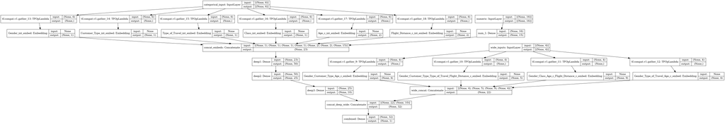

```python
plot_model(
    model, to_file='model.png', show_shapes=True, show_layer_names=True,
    rankdir='TB', expand_nested=False, dpi=96
)
# rankdir='LR'
# model.summary()
```

```python
%%time

model.compile(optimizer='adagrad',
              loss='mean_squared_error',
              metrics=['accuracy'])

# lets also add the history variable to see how we are doing
# and lets add a validation set to keep track of our progress
history = model.fit([X_train_crossed,X_train_cat,X_train_num],
                    y_train,
                    epochs=200,
                    batch_size=32,
                    verbose=1,
                    validation_data = ([X_test_crossed,X_test_cat,X_test_num],y_test))
```

```
CPU times: user 23min 21s, sys: 11min 45s, total: 35min 6s
Wall time: 9min 31s
```

```python
yhat = np.round(model.predict([X_test_crossed,X_test_cat,X_test_num]))
print(mt.confusion_matrix(y_test,yhat))
print(mt.classification_report(y_test,yhat))
```

```
[[11127   613]
 [  861  8118]]
              precision    recall  f1-score   support

           0       0.93      0.95      0.94     11740
           1       0.93      0.90      0.92      8979

    accuracy                           0.93     20719
   macro avg       0.93      0.93      0.93     20719
weighted avg       0.93      0.93      0.93     20719
```

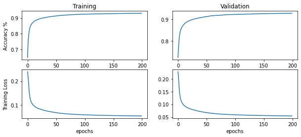

```python
from matplotlib import pyplot as plt

%matplotlib inline

plt.figure(figsize=(10,4))
plt.subplot(2,2,1)
plt.plot(history.history['accuracy'])

plt.ylabel('Accuracy %')
plt.title('Training')
plt.subplot(2,2,2)
plt.plot(history.history['val_accuracy'])
plt.title('Validation')

plt.subplot(2,2,3)
plt.plot(history.history['loss'])
plt.ylabel('Training Loss')
plt.xlabel('epochs')

plt.subplot(2,2,4)
plt.plot(history.history['val_loss'])
plt.xlabel('epochs')
```

Model 2 uses 'adagrad' as the optimizer, 'mean_squared_error' as the loss function and accuracy as the performance metric. We ran the model 200 iterations and training converges after about 150 epochs. The overall accuracy of model 2 is about 93% and the precision for both target classes is 93%.

### Model 3: the third wide and deep model

Model 3 is the third wide and deep neural network model we created. It is modified based on model 2. The major difference between model 3 and model 2 is that the former has 75, 50, 20 neurons in the hidden layers of the deep branch.

```python
categorical_headers_ints = [x+'_int' for x in categorical_headers]
y_train = df_train['satisfaction']
y_test = df_test['satisfaction']

cross_columns = [['Gender', 'Customer_Type','Age_c'],
                 ['Gender', 'Customer_Type', 'Type_of_Travel', 'Flight_Distance_c'],
                 ['Gender',  'Class', 'Age_c', 'Flight_Distance_c'],
                 ['Gender', 'Type_of_Travel', 'Age_c']]

# cross each set of columns in the list above
cross_col_df_names = []
for cols_list in cross_columns:
    # encode as ints for the embedding
    enc = LabelEncoder()

    # 1. create crossed labels by join operation
    X_crossed_train = df_train[cols_list].apply(lambda x: '_'.join(x), axis=1)
    X_crossed_test = df_test[cols_list].apply(lambda x: '_'.join(x), axis=1)

    # get a nice name for this new crossed column
    cross_col_name = '_'.join(cols_list)

    # 2. encode as integers
    enc.fit(np.hstack((X_crossed_train.to_numpy(),  X_crossed_test.to_numpy())))

    # 3. Save into dataframe with new name
    df_train[cross_col_name] = enc.transform(X_crossed_train)
    df_test[cross_col_name] = enc.transform(X_crossed_test)

    # keep track of the new names of the crossed columns
    cross_col_df_names.append(cross_col_name)
# get crossed columns
X_train_crossed = df_train[cross_col_df_names].to_numpy()
X_test_crossed = df_test[cross_col_df_names].to_numpy()

# save categorical features
X_train_cat = df_train[categorical_headers_ints].to_numpy()
X_test_cat = df_test[categorical_headers_ints].to_numpy()

# and save off the numeric features
X_train_num =  df_train[numeric_headers].to_numpy()
X_test_num = df_test[numeric_headers].to_numpy()


# we need to create separate lists for each branch
crossed_outputs = []

# CROSSED DATA INPUT
input_crossed = Input(shape=(X_train_crossed.shape[1],), dtype='int64', name='wide_inputs')
for idx,col in enumerate(cross_col_df_names):

    # track what the maximum integer value will be for this variable
    # which is the same as the number of categories
    N = max(df_train[col].max(),df_test[col].max())+1


    # this line of code does this: input_branch[:,idx]
    x = tf.gather(input_crossed, idx, axis=1)

    # now use an embedding to deal with integers as if they were one hot encoded
    x = Embedding(input_dim=N,
                  output_dim=int(np.sqrt(N)),
                  input_length=1, name=col+'_embed')(x)

    # save these outputs to concatenate later
    crossed_outputs.append(x)


# now concatenate the outputs and add a fully connected layer
wide_branch = concatenate(crossed_outputs, name='wide_concat')

# reset this input branch
all_deep_branch_outputs = []

# CATEGORICAL DATA INPUT
input_cat = Input(shape=(X_train_cat.shape[1],), dtype='int64', name='categorical_input')
for idx,col in enumerate(categorical_headers_ints):

    # track what the maximum integer value will be for this variable
    # which is the same as the number of categories
    N = max(df_train[col].max(),df_test[col].max())+1

    # this line of code does this: input_branch[:,idx]
    x = tf.gather(input_cat, idx, axis=1)

    # now use an embedding to deal with integers as if they were one hot encoded
    x = Embedding(input_dim=N,
                  output_dim=int(np.sqrt(N)),
                  input_length=1, name=col+'_embed')(x)

    # save these outputs to concatenate later
    all_deep_branch_outputs.append(x)

# NUMERIC DATA INPUT
# create dense input branch for numeric
input_num = Input(shape=(X_train_num.shape[1],), name='numeric')
x_dense = Dense(units=15, activation='relu',name='num_1')(input_num)

all_deep_branch_outputs.append(x_dense)


# merge the deep branches together
deep_branch = concatenate(all_deep_branch_outputs,name='concat_embeds')
deep_branch = Dense(units=75,activation='relu', name='deep1')(deep_branch)
deep_branch = Dense(units=50,activation='relu', name='deep2')(deep_branch)
deep_branch = Dense(units=20,activation='relu', name='deep3')(deep_branch)

# merge the deep and wide branch
final_branch = concatenate([wide_branch, deep_branch],
                           name='concat_deep_wide')
final_branch = Dense(units=1,activation='sigmoid',
                     name='combined')(final_branch)

model = Model(inputs=[input_crossed,input_cat,input_num],
              outputs=final_branch)
```

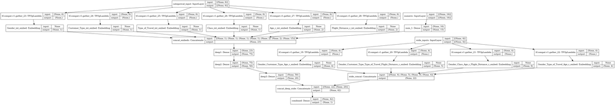

```python
plot_model(
    model, to_file='model.png', show_shapes=True, show_layer_names=True,
    rankdir='TB', expand_nested=False, dpi=96
)
# rankdir='LR'
# model.summary()
```

```python
%%time

model.compile(optimizer='adagrad',
              loss='mean_squared_error',
              metrics=['accuracy'])

# lets also add the history variable to see how we are doing
# and lets add a validation set to keep track of our progress
history = model.fit([X_train_crossed,X_train_cat,X_train_num],
                    y_train,
                    epochs=200,
                    batch_size=32,
                    verbose=1,
                    validation_data = ([X_test_crossed,X_test_cat,X_test_num],y_test))
```

```
CPU times: user 24min 44s, sys: 12min 39s, total: 37min 24s
Wall time: 9min 56s
```

```python
yhat = np.round(model.predict([X_test_crossed,X_test_cat,X_test_num]))
print(mt.confusion_matrix(y_test,yhat))
print(mt.classification_report(y_test,yhat))
```

```
[[11156   584]
 [  824  8155]]
              precision    recall  f1-score   support

           0       0.93      0.95      0.94     11740
           1       0.93      0.91      0.92      8979

    accuracy                           0.93     20719
   macro avg       0.93      0.93      0.93     20719
weighted avg       0.93      0.93      0.93     20719
```

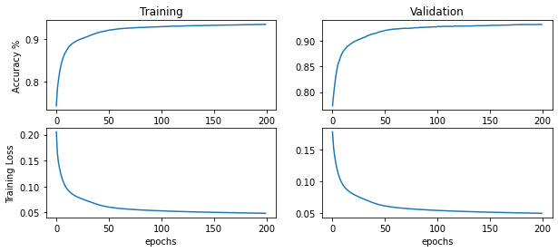

```python
from matplotlib import pyplot as plt

%matplotlib inline

plt.figure(figsize=(10,4))
plt.subplot(2,2,1)
plt.plot(history.history['accuracy'])

plt.ylabel('Accuracy %')
plt.title('Training')
plt.subplot(2,2,2)
plt.plot(history.history['val_accuracy'])
plt.title('Validation')

plt.subplot(2,2,3)
plt.plot(history.history['loss'])
plt.ylabel('Training Loss')
plt.xlabel('epochs')

plt.subplot(2,2,4)
plt.plot(history.history['val_loss'])
plt.xlabel('epochs')
```

Model 3 also uses 'adagrad' as the optimizer, 'mean_squared_error' as the loss function and accuracy as the performance metric. We ran the model 200 iterations and training converges after about 150 epochs. The overall accuracy of model 3 is about 93% and the precision for both target classes is 93%.

### Model 4: the fourth wide and deep model

Model 4 is the fourth wide and deep neural network model we created. It is modified based on model 3. The major difference between model 4 and model 3 is that it has 7 layers in the deep branch of the network.

```python
categorical_headers_ints = [x+'_int' for x in categorical_headers]
y_train = df_train['satisfaction']
y_test = df_test['satisfaction']

cross_columns = [['Gender', 'Customer_Type','Age_c'],
                 ['Gender', 'Customer_Type', 'Type_of_Travel', 'Flight_Distance_c'],
                 ['Gender',  'Class', 'Age_c', 'Flight_Distance_c'],
                 ['Gender', 'Type_of_Travel', 'Age_c']]

# cross each set of columns in the list above
cross_col_df_names = []
for cols_list in cross_columns:
    # encode as ints for the embedding
    enc = LabelEncoder()

    # 1. create crossed labels by join operation
    X_crossed_train = df_train[cols_list].apply(lambda x: '_'.join(x), axis=1)
    X_crossed_test = df_test[cols_list].apply(lambda x: '_'.join(x), axis=1)

    # get a nice name for this new crossed column
    cross_col_name = '_'.join(cols_list)

    # 2. encode as integers
    enc.fit(np.hstack((X_crossed_train.to_numpy(),  X_crossed_test.to_numpy())))

    # 3. Save into dataframe with new name
    df_train[cross_col_name] = enc.transform(X_crossed_train)
    df_test[cross_col_name] = enc.transform(X_crossed_test)

    # keep track of the new names of the crossed columns
    cross_col_df_names.append(cross_col_name)
# get crossed columns
X_train_crossed = df_train[cross_col_df_names].to_numpy()
X_test_crossed = df_test[cross_col_df_names].to_numpy()

# save categorical features
X_train_cat = df_train[categorical_headers_ints].to_numpy()
X_test_cat = df_test[categorical_headers_ints].to_numpy()

# and save off the numeric features
X_train_num =  df_train[numeric_headers].to_numpy()
X_test_num = df_test[numeric_headers].to_numpy()


# we need to create separate lists for each branch
crossed_outputs = []

# CROSSED DATA INPUT
input_crossed = Input(shape=(X_train_crossed.shape[1],), dtype='int64', name='wide_inputs')
for idx,col in enumerate(cross_col_df_names):

    # track what the maximum integer value will be for this variable
    # which is the same as the number of categories
    N = max(df_train[col].max(),df_test[col].max())+1


    # this line of code does this: input_branch[:,idx]
    x = tf.gather(input_crossed, idx, axis=1)

    # now use an embedding to deal with integers as if they were one hot encoded
    x = Embedding(input_dim=N,
                  output_dim=int(np.sqrt(N)),
                  input_length=1, name=col+'_embed')(x)

    # save these outputs to concatenate later
    crossed_outputs.append(x)


# now concatenate the outputs and add a fully connected layer
wide_branch = concatenate(crossed_outputs, name='wide_concat')

# reset this input branch
all_deep_branch_outputs = []

# CATEGORICAL DATA INPUT
input_cat = Input(shape=(X_train_cat.shape[1],), dtype='int64', name='categorical_input')
for idx,col in enumerate(categorical_headers_ints):

    # track what the maximum integer value will be for this variable
    # which is the same as the number of categories
    N = max(df_train[col].max(),df_test[col].max())+1

    # this line of code does this: input_branch[:,idx]
    x = tf.gather(input_cat, idx, axis=1)

    # now use an embedding to deal with integers as if they were one hot encoded
    x = Embedding(input_dim=N,
                  output_dim=int(np.sqrt(N)),
                  input_length=1, name=col+'_embed')(x)

    # save these outputs to concatenate later
    all_deep_branch_outputs.append(x)

# NUMERIC DATA INPUT
# create dense input branch for numeric
input_num = Input(shape=(X_train_num.shape[1],), name='numeric')
x_dense = Dense(units=15, activation='relu',name='num_1')(input_num)

all_deep_branch_outputs.append(x_dense)


# merge the deep branches together
deep_branch = concatenate(all_deep_branch_outputs,name='concat_embeds')
deep_branch = Dense(units=100,activation='relu', name='deep1')(deep_branch)
deep_branch = Dense(units=80,activation='relu', name='deep2')(deep_branch)
deep_branch = Dense(units=60,activation='relu', name='deep3')(deep_branch)
deep_branch = Dense(units=50,activation='relu', name='deep4')(deep_branch)
deep_branch = Dense(units=40,activation='relu', name='deep5')(deep_branch)
deep_branch = Dense(units=20,activation='relu', name='deep6')(deep_branch)
deep_branch = Dense(units=10,activation='relu', name='deep7')(deep_branch)

# merge the deep and wide branch
final_branch = concatenate([wide_branch, deep_branch],
                           name='concat_deep_wide')
final_branch = Dense(units=1,activation='sigmoid',
                     name='combined')(final_branch)

model = Model(inputs=[input_crossed,input_cat,input_num],
              outputs=final_branch)
```

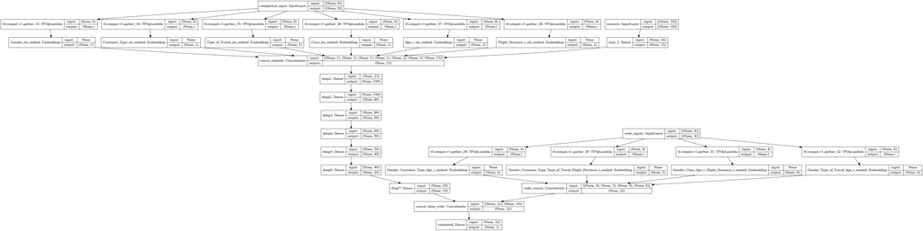

```python
plot_model(
    model, to_file='model.png', show_shapes=True, show_layer_names=True,
    rankdir='TB', expand_nested=False, dpi=96
)
# rankdir='LR'
# model.summary()
```

```python
%%time

model.compile(optimizer='adagrad',
              loss='mean_squared_error',
              metrics=['accuracy'])

# lets also add the history variable to see how we are doing
# and lets add a validation set to keep track of our progress
history = model.fit([X_train_crossed,X_train_cat,X_train_num],
                    y_train,
                    epochs=200,
                    batch_size=32,
                    verbose=1,
                    validation_data = ([X_test_crossed,X_test_cat,X_test_num],y_test))
```

```
CPU times: user 27min 40s, sys: 12min 47s, total: 40min 27s
Wall time: 11min 17s
```

```python
yhat = np.round(model.predict([X_test_crossed,X_test_cat,X_test_num]))
print(mt.confusion_matrix(y_test,yhat))
print(mt.classification_report(y_test,yhat))
```

```
[[11244   496]
 [  822  8157]]
              precision    recall  f1-score   support

           0       0.93      0.96      0.94     11740
           1       0.94      0.91      0.93      8979

    accuracy                           0.94     20719
   macro avg       0.94      0.93      0.93     20719
weighted avg       0.94      0.94      0.94     20719
```

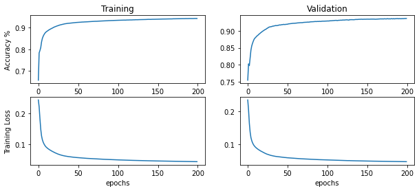

```python
plt.figure(figsize=(10,4))
plt.subplot(2,2,1)
plt.plot(history.history['accuracy'])

plt.ylabel('Accuracy %')
plt.title('Training')
plt.subplot(2,2,2)
plt.plot(history.history['val_accuracy'])
plt.title('Validation')

plt.subplot(2,2,3)
plt.plot(history.history['loss'])
plt.ylabel('Training Loss')
plt.xlabel('epochs')

plt.subplot(2,2,4)
plt.plot(history.history['val_loss'])
plt.xlabel('epochs')
```

Model 4 also uses 'adagrad' as the optimizer, 'mean_squared_error' as the loss function and accuracy as the performance metric.

### Model 5: the fifth wide and deep model

Model 5 is the fifth wide and deep neural network model we created. It is modified based on model 4. The major difference between model 5 and model 4 is that it has 12 layers in the deep branch of the network.

```python
categorical_headers_ints = [x+'_int' for x in categorical_headers]
y_train = df_train['satisfaction']
y_test = df_test['satisfaction']

cross_columns = [['Gender', 'Customer_Type','Age_c'],
                 ['Gender', 'Customer_Type', 'Type_of_Travel', 'Flight_Distance_c'],
                 ['Gender',  'Class', 'Age_c', 'Flight_Distance_c'],
                 ['Gender', 'Type_of_Travel', 'Age_c']]

# cross each set of columns in the list above
cross_col_df_names = []
for cols_list in cross_columns:
    # encode as ints for the embedding
    enc = LabelEncoder()

    # 1. create crossed labels by join operation
    X_crossed_train = df_train[cols_list].apply(lambda x: '_'.join(x), axis=1)
    X_crossed_test = df_test[cols_list].apply(lambda x: '_'.join(x), axis=1)

    # get a nice name for this new crossed column
    cross_col_name = '_'.join(cols_list)

    # 2. encode as integers
    enc.fit(np.hstack((X_crossed_train.to_numpy(),  X_crossed_test.to_numpy())))

    # 3. Save into dataframe with new name
    df_train[cross_col_name] = enc.transform(X_crossed_train)
    df_test[cross_col_name] = enc.transform(X_crossed_test)

    # keep track of the new names of the crossed columns
    cross_col_df_names.append(cross_col_name)
# get crossed columns
X_train_crossed = df_train[cross_col_df_names].to_numpy()
X_test_crossed = df_test[cross_col_df_names].to_numpy()

# save categorical features
X_train_cat = df_train[categorical_headers_ints].to_numpy()
X_test_cat = df_test[categorical_headers_ints].to_numpy()

# and save off the numeric features
X_train_num =  df_train[numeric_headers].to_numpy()
X_test_num = df_test[numeric_headers].to_numpy()


# we need to create separate lists for each branch
crossed_outputs = []

# CROSSED DATA INPUT
input_crossed = Input(shape=(X_train_crossed.shape[1],), dtype='int64', name='wide_inputs')
for idx,col in enumerate(cross_col_df_names):

    # track what the maximum integer value will be for this variable
    # which is the same as the number of categories
    N = max(df_train[col].max(),df_test[col].max())+1


    # this line of code does this: input_branch[:,idx]
    x = tf.gather(input_crossed, idx, axis=1)

    # now use an embedding to deal with integers as if they were one hot encoded
    x = Embedding(input_dim=N,
                  output_dim=int(np.sqrt(N)),
                  input_length=1, name=col+'_embed')(x)

    # save these outputs to concatenate later
    crossed_outputs.append(x)


# now concatenate the outputs and add a fully connected layer
wide_branch = concatenate(crossed_outputs, name='wide_concat')

# reset this input branch
all_deep_branch_outputs = []

# CATEGORICAL DATA INPUT
input_cat = Input(shape=(X_train_cat.shape[1],), dtype='int64', name='categorical_input')
for idx,col in enumerate(categorical_headers_ints):

    # track what the maximum integer value will be for this variable
    # which is the same as the number of categories
    N = max(df_train[col].max(),df_test[col].max())+1

    # this line of code does this: input_branch[:,idx]
    x = tf.gather(input_cat, idx, axis=1)

    # now use an embedding to deal with integers as if they were one hot encoded
    x = Embedding(input_dim=N,
                  output_dim=int(np.sqrt(N)),
                  input_length=1, name=col+'_embed')(x)

    # save these outputs to concatenate later
    all_deep_branch_outputs.append(x)

# NUMERIC DATA INPUT
# create dense input branch for numeric
input_num = Input(shape=(X_train_num.shape[1],), name='numeric')
x_dense = Dense(units=15, activation='relu',name='num_1')(input_num)

all_deep_branch_outputs.append(x_dense)


# merge the deep branches together
deep_branch = concatenate(all_deep_branch_outputs,name='concat_embeds')
deep_branch = Dense(units=200,activation='relu', name='deep1')(deep_branch)
deep_branch = Dense(units=180,activation='relu', name='deep2')(deep_branch)
deep_branch = Dense(units=160,activation='relu', name='deep3')(deep_branch)
deep_branch = Dense(units=140,activation='relu', name='deep4')(deep_branch)
deep_branch = Dense(units=120,activation='relu', name='deep5')(deep_branch)
deep_branch = Dense(units=100,activation='relu', name='deep6')(deep_branch)
deep_branch = Dense(units=80,activation='relu', name='deep7')(deep_branch)
deep_branch = Dense(units=60,activation='relu', name='deep8')(deep_branch)
deep_branch = Dense(units=40,activation='relu', name='deep9')(deep_branch)
deep_branch = Dense(units=30,activation='relu', name='deep10')(deep_branch)
deep_branch = Dense(units=20,activation='relu', name='deep11')(deep_branch)
deep_branch = Dense(units=10,activation='relu', name='deep12')(deep_branch)

# merge the deep and wide branch
final_branch = concatenate([wide_branch, deep_branch],
                           name='concat_deep_wide')
final_branch = Dense(units=1,activation='sigmoid',
                     name='combined')(final_branch)

model = Model(inputs=[input_crossed,input_cat,input_num],
              outputs=final_branch)
```

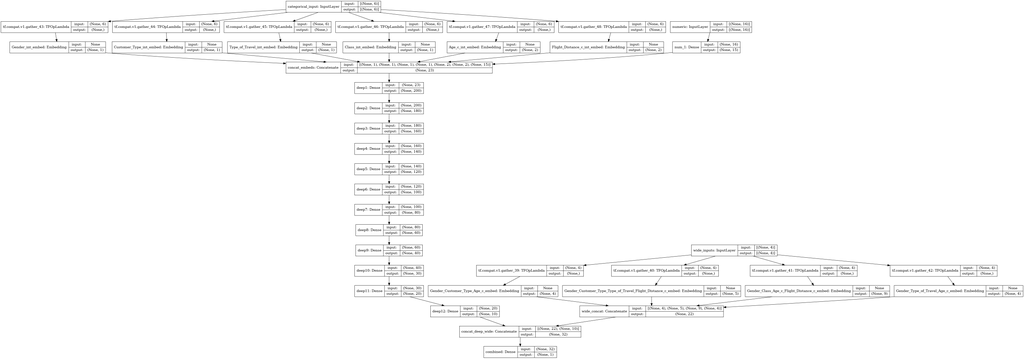

```python
plot_model(
    model, to_file='model.png', show_shapes=True, show_layer_names=True,
    rankdir='TB', expand_nested=False, dpi=96
)
# rankdir='LR'
# model.summary()
```

```python
%%time

model.compile(optimizer='adagrad',
              loss='mean_squared_error',
              metrics=['accuracy'])

# lets also add the history variable to see how we are doing
# and lets add a validation set to keep track of our progress
history = model.fit([X_train_crossed,X_train_cat,X_train_num],
                    y_train,
                    epochs=150,
                    batch_size=32,
                    verbose=1,
                    validation_data = ([X_test_crossed,X_test_cat,X_test_num],y_test))
```

```
CPU times: user 34min 8s, sys: 15min 35s, total: 49min 43s
Wall time: 14min 15s
```

```python
yhat5 = np.round(model.predict([X_test_crossed,X_test_cat,X_test_num]))

print(mt.confusion_matrix(y_test,yhat5))
print(mt.classification_report(y_test,yhat5))
```

```
[[11256   484]
 [  795  8184]]
              precision    recall  f1-score   support

           0       0.93      0.96      0.95     11740
           1       0.94      0.91      0.93      8979

    accuracy                           0.94     20719
   macro avg       0.94      0.94      0.94     20719
weighted avg       0.94      0.94      0.94     20719
```

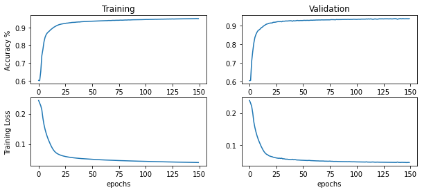

```python
from matplotlib import pyplot as plt

%matplotlib inline

plt.figure(figsize=(10,4))
plt.subplot(2,2,1)
plt.plot(history.history['accuracy'])

plt.ylabel('Accuracy %')
plt.title('Training')
plt.subplot(2,2,2)
plt.plot(history.history['val_accuracy'])
plt.title('Validation')

plt.subplot(2,2,3)
plt.plot(history.history['loss'])
plt.ylabel('Training Loss')
plt.xlabel('epochs')

plt.subplot(2,2,4)
plt.plot(history.history['val_loss'])
plt.xlabel('epochs')
```

Model 5 also uses 'adagrad' as the optimizer, 'mean_squared_error' as the loss function and accuracy as the performance metric.

#### Comparing the performance of our best model with wide and deep network with the model with only the deep network using receiver operating characteristic (ROC) curve and the area under the curve

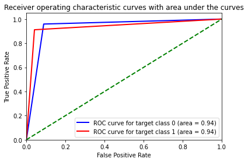

```python
# need to onehot encode both y_test and yhat


from sklearn.metrics import roc_curve, auc
from sklearn.metrics import roc_auc_score

y_test_onehot = pd.get_dummies(y_test).values
yhat5_onehot = pd.get_dummies(yhat5.reshape(-1,)).values

# print(yhat_onehot)
n_classes = y_test_onehot.shape[1]

# print(yhat)

# Compute ROC curve and ROC area for each class
fpr = dict()
tpr = dict()
roc_auc = dict()
for i in range(n_classes):
    fpr[i], tpr[i], _ = roc_curve(y_test_onehot[:, i], yhat5_onehot[:, i])
    roc_auc[i] = auc(fpr[i], tpr[i])

    # Compute micro-average ROC curve and ROC area
fpr["micro"], tpr["micro"], _ = roc_curve(y_test_onehot.ravel(), yhat5_onehot.ravel())
roc_auc["micro"] = auc(fpr["micro"], tpr["micro"])

plt.figure()
lw = 2
plt.plot(fpr[0], tpr[0], color='blue',
         lw=lw, label='ROC curve for target class 0 (area = %0.2f)' % roc_auc[0])
plt.plot(fpr[1], tpr[1], color='red',
         lw=lw, label='ROC curve for target class 1 (area = %0.2f)' % roc_auc[1])

plt.plot([0, 1], [0, 1], color='green', lw=lw, linestyle='--')
plt.xlim([0.0, 1.0])
plt.ylim([0.0, 1.05])
plt.xlabel('False Positive Rate')
plt.ylabel('True Positive Rate')
plt.title('Receiver operating characteristic curves with area under the curves')
plt.legend(loc="lower right")
plt.show()
```

### Model 6: a deep neural network model without the wide branch

Model 6 has no wide branches. It uses both embeded categorical attributes and normalized numerical attributes to create the deep branch.

```python
# save categorical features
X_train_cat = df_train[categorical_headers_ints].to_numpy()
X_test_cat = df_test[categorical_headers_ints].to_numpy()

# and save off the numeric features
X_train_num =  df_train[numeric_headers].to_numpy()
X_test_num = df_test[numeric_headers].to_numpy()

all_branch_outputs = [] # this is where we will keep track of output of each branch

input_cat = Input(shape=(X_train_cat.shape[1],), dtype='int64', name='categorical')
for idx,col in enumerate(categorical_headers_ints):

    # track what the maximum integer value will be for this variable
    # which is the same as the number of categories
    N = max(df_train[col].max(),df_test[col].max())+1


    # this line of code does this: input_branch[:,idx]
    x = tf.gather(input_cat, idx, axis=1)

    # now use an embedding to deal with integers as if they were one hot encoded
    x = Embedding(input_dim=N,
                  output_dim=int(np.sqrt(N)),
                  input_length=1, name=col+'_embed')(x)

    # save these outputs to concatenate later
    all_branch_outputs.append(x)

# HERE IS THE ADDING OF AN INPUT USING NUMERIC DATA
# create dense input branch for numeric
inputs_num = Input(shape=(X_train_num.shape[1],), name='numeric')
x_dense = Dense(units=15, activation='relu',name='num_1')(inputs_num)

all_branch_outputs.append(x_dense)

# now concatenate the outputs and add a fully connected layer
final_branch = concatenate(all_branch_outputs, name='concat_1')
final_branch = Dense(units=200,activation='relu', name='combined_1')(final_branch)
final_branch = Dense(units=180,activation='relu', name='combined_2')(final_branch)
final_branch = Dense(units=160,activation='relu', name='combined_3')(final_branch)
final_branch = Dense(units=140,activation='relu', name='combined_4')(final_branch)
final_branch = Dense(units=120,activation='relu', name='combined_5')(final_branch)
final_branch = Dense(units=100,activation='relu', name='combined_6')(final_branch)
final_branch = Dense(units=80,activation='relu', name='combined_7')(final_branch)
final_branch = Dense(units=60,activation='relu', name='combined_8')(final_branch)
final_branch = Dense(units=40,activation='relu', name='combined_9')(final_branch)
final_branch = Dense(units=30,activation='relu', name='combined_10')(final_branch)
final_branch = Dense(units=20,activation='relu', name='combined_11')(final_branch)
final_branch = Dense(units=10,activation='relu', name='combined_12')(final_branch)


final_branch = Dense(units=1,activation='sigmoid',
                     name='combined')(final_branch)

model = Model(inputs=[input_cat,inputs_num], outputs=final_branch)

model.compile(optimizer='sgd',
              loss='mean_squared_error',
              metrics=['accuracy'])

model.summary()
```

```
Model: "model_8"
__________________________________________________________________________________________________
Layer (type)                    Output Shape         Param #     Connected to
==================================================================================================
categorical (InputLayer)        [(None, 6)]          0
__________________________________________________________________________________________________
tf.compat.v1.gather_67 (TFOpLam (None,)              0           categorical[0][0]
__________________________________________________________________________________________________
tf.compat.v1.gather_68 (TFOpLam (None,)              0           categorical[0][0]
__________________________________________________________________________________________________
tf.compat.v1.gather_69 (TFOpLam (None,)              0           categorical[0][0]
__________________________________________________________________________________________________
tf.compat.v1.gather_70 (TFOpLam (None,)              0           categorical[0][0]
__________________________________________________________________________________________________
tf.compat.v1.gather_71 (TFOpLam (None,)              0           categorical[0][0]
__________________________________________________________________________________________________
tf.compat.v1.gather_72 (TFOpLam (None,)              0           categorical[0][0]
__________________________________________________________________________________________________
numeric (InputLayer)            [(None, 16)]         0
__________________________________________________________________________________________________
Gender_int_embed (Embedding)    (None, 1)            2           tf.compat.v1.gather_67[0][0]
__________________________________________________________________________________________________
Customer_Type_int_embed (Embedd (None, 1)            2           tf.compat.v1.gather_68[0][0]
__________________________________________________________________________________________________
Type_of_Travel_int_embed (Embed (None, 1)            2           tf.compat.v1.gather_69[0][0]
__________________________________________________________________________________________________
Class_int_embed (Embedding)     (None, 1)            3           tf.compat.v1.gather_70[0][0]
__________________________________________________________________________________________________
Age_c_int_embed (Embedding)     (None, 2)            8           tf.compat.v1.gather_71[0][0]
__________________________________________________________________________________________________
Flight_Distance_c_int_embed (Em (None, 2)            8           tf.compat.v1.gather_72[0][0]
__________________________________________________________________________________________________
num_1 (Dense)                   (None, 15)           255         numeric[0][0]
__________________________________________________________________________________________________
concat_1 (Concatenate)          (None, 23)           0           Gender_int_embed[0][0]
                                                                 Customer_Type_int_embed[0][0]
                                                                 Type_of_Travel_int_embed[0][0]
                                                                 Class_int_embed[0][0]
                                                                 Age_c_int_embed[0][0]
                                                                 Flight_Distance_c_int_embed[0][0]
```

[output cut: 17 more lines]

```
__________________________________________________________________________________________________
combined_9 (Dense)              (None, 40)           2440        combined_8[0][0]
__________________________________________________________________________________________________
combined_10 (Dense)             (None, 30)           1230        combined_9[0][0]
__________________________________________________________________________________________________
combined_11 (Dense)             (None, 20)           620         combined_10[0][0]
__________________________________________________________________________________________________
combined_12 (Dense)             (None, 10)           210         combined_11[0][0]
__________________________________________________________________________________________________
combined (Dense)                (None, 1)            11          combined_12[0][0]
==================================================================================================
Total params: 139,231
Trainable params: 139,231
Non-trainable params: 0
__________________________________________________________________________________________________
```

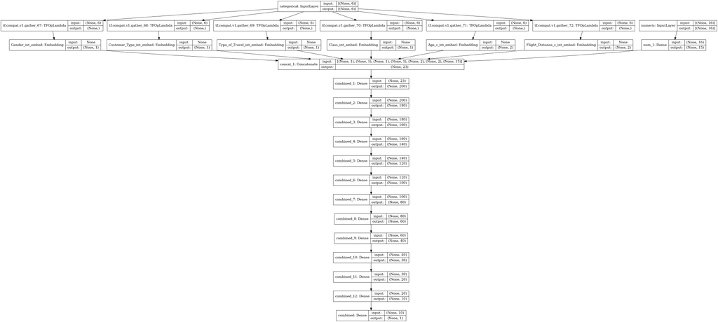

```python
plot_model(
    model, to_file='model.png', show_shapes=True, show_layer_names=True,
    rankdir='TB', expand_nested=False, dpi=96)
```

```python
%%time

model.compile(optimizer='sgd',
              loss='mean_squared_error',
              metrics=['accuracy'])

model.fit([ X_train_cat, X_train_num ], # inputs for each branch are a list
          y_train,
          epochs=150,
          batch_size=50,
          verbose=1)

yhat6 = model.predict([X_test_cat,
                      X_test_num]) # each branch has an input

yhat6 = np.round(yhat6)
print(mt.confusion_matrix(y_test,yhat6))
print(mt.classification_report(y_test,yhat6))
```

```
[[11365   375]
 [  639  8340]]
              precision    recall  f1-score   support

           0       0.95      0.97      0.96     11740
           1       0.96      0.93      0.94      8979

    accuracy                           0.95     20719
   macro avg       0.95      0.95      0.95     20719
weighted avg       0.95      0.95      0.95     20719

CPU times: user 20min 10s, sys: 10min 9s, total: 30min 19s
Wall time: 9min 4s
```

[figure not shown]

```python
from matplotlib import pyplot as plt

%matplotlib inline

plt.figure(figsize=(10,4))
plt.subplot(2,2,1)
plt.plot(history.history['accuracy'])

plt.ylabel('Accuracy %')
plt.title('Training')
plt.subplot(2,2,2)
plt.plot(history.history['val_accuracy'])
plt.title('Validation')

plt.subplot(2,2,3)
plt.plot(history.history['loss'])
plt.ylabel('Training Loss')
plt.xlabel('epochs')

plt.subplot(2,2,4)
plt.plot(history.history['val_loss'])
plt.xlabel('epochs')
```

### Comparing the performance of our best model with wide and deep network with the model with only the deep network using receiver operating characteristic (ROC) curve and the area under the curve

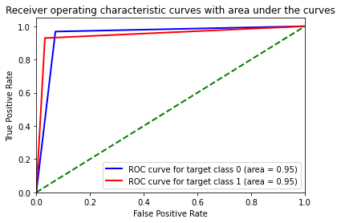

```python
# need to onehot encode both y_test and yhat

# [6]Receiver Operating Characteristic (ROC)
# https://scikit-learn.org/stable/auto_examples/model_selection/plot_roc.html

y_test_onehot = pd.get_dummies(y_test).values
yhat6_onehot = pd.get_dummies(yhat6.reshape(-1,)).values

# print(yhat_onehot)
n_classes = y_test_onehot.shape[1]

# print(yhat)

# Compute ROC curve and ROC area for each class
fpr = dict()
tpr = dict()
roc_auc = dict()
for i in range(n_classes):
    fpr[i], tpr[i], _ = roc_curve(y_test_onehot[:, i], yhat6_onehot[:, i])
    roc_auc[i] = auc(fpr[i], tpr[i])

    # Compute micro-average ROC curve and ROC area
fpr["micro"], tpr["micro"], _ = roc_curve(y_test_onehot.ravel(), yhat6_onehot.ravel())
roc_auc["micro"] = auc(fpr["micro"], tpr["micro"])

plt.figure()
lw = 2
plt.plot(fpr[0], tpr[0], color='blue',
         lw=lw, label='ROC curve for target class 0 (area = %0.2f)' % roc_auc[0])
plt.plot(fpr[1], tpr[1], color='red',
         lw=lw, label='ROC curve for target class 1 (area = %0.2f)' % roc_auc[1])

plt.plot([0, 1], [0, 1], color='green', lw=lw, linestyle='--')
plt.xlim([0.0, 1.0])
plt.ylim([0.0, 1.05])
plt.xlabel('False Positive Rate')
plt.ylabel('True Positive Rate')
plt.title('Receiver operating characteristic curves with area under the curves')
plt.legend(loc="lower right")
plt.show()
```

### Statistical comparison of model performance using McNemar tests

```python
# y_test is the true y values from the test data
# model1_pred  is the predicted y values from model 1
# model2_pred is the predicted y values from model 2

def create_contingency_MacNemar(y_test, model1_pred, model2_pred):

    correct1_correct2 = 0  # model 1 predict correctly, model 2 also predict correctly
    correct1_wrong2 = 0 # model 1 predict correctly, model 2 predict wrong
    wrong1_correct2 = 0
    wrong1_wrong2 = 0

    for i in range(len(y_test)):
        if model1_pred[i] == y_test[i] and model2_pred[i] == y_test[i]:
            correct1_correct2 +=1
        elif model1_pred[i] == y_test[i] and model2_pred[i] != y_test[i]:
            correct1_wrong2 +=1
        elif model1_pred[i] != y_test[i] and model2_pred[i] == y_test[i]:
            wrong1_correct2 +=1
        else:
            wrong1_wrong2 +=1
    return [[correct1_correct2, correct1_wrong2], [wrong1_correct2, wrong1_wrong2]]

# https://machinelearningmastery.com/mcnemars-test-for-machine-learning/

# Example of calculating the mcnemar test
from statsmodels.stats.contingency_tables import mcnemar
# define contingency table

def cal_mcnemar(table):

    # calculate mcnemar test
    print(table)
    result = mcnemar(table, exact=True)
    # summarize the finding
    print('statistic=%.3f, p-value=%.3f' % (result.statistic, result.pvalue))
    # interpret the p-value
    alpha = 0.05
    if result.pvalue > alpha:
        print('Same accuracy (fail to reject H0)')
    else:
        print('Different accuracy (reject H0)')
```

#### McNemar test for model 5 and model 6

```python
table = create_contingency_MacNemar(y_test, yhat5, yhat6)
cal_mcnemar(table)
```

```
[[19031, 409], [674, 605]]
statistic=409.000, p-value=0.000
Different accuracy (reject H0)
```

We reject the Null Hypothesis. Using significance level alpha = 0.05, we have sufficient evidence that model 5 and model 6 are different from each other.

The accuracy of model 6 is higher than model 5. Therefore, we conclude model 6 has a better performance.

## Exceptional work

### Capture and visualization of the embedding weights

```python
df_weights = pd.DataFrame()

for layer_index, layer in enumerate(model.layers):

    if (layer.name.find('embed') != -1):
        df_weights[layer.name] = layer.get_weights()

df_weights.head()
```

|  | Gender_int_embed | Customer_Type_int_embed | Type_of_Travel_int_embed | Class_int_embed | Age_c_int_embed | Flight_Distance_c_int_embed |
| --- | --- | --- | --- | --- | --- | --- |
| 0 | [[-0.2726169], [0.06473267]] | [[-0.5009519], [0.7282902]] | [[0.51597196], [-0.8140861]] | [[0.65797025], [-0.3991798], [-0.309789]] | [[0.24277723, 0.37779123], [-0.13566741, -0.06... | [[-0.24139932, 0.17223899], [-0.09384124, -0.2... |

### Store label Encoded mapping

```python
gender_map = encoders['Gender'].fit(['male', 'female']).classes_
cutomer_type_map = encoders['Customer_Type'].fit(['Loyal Customer', 'disloyal Customer']).classes_
type_of_travel_map = encoders['Type_of_Travel'].fit(['Personal Travel', 'Business travel']).classes_
class_map = encoders['Class'].fit(['Eco', 'Eco Plus', 'Business']).classes_
age_map = encoders['Age_c'].fit(['child', 'teen', 'young', 'adult']).classes_
flight_distance_map = encoders['Flight_Distance_c'].fit(['short_haul', 'long_haul','medium_haul', 'ultra_long_haul']).classes_
```

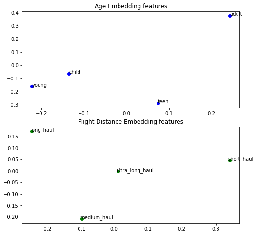

```python
age_x = df_weights['Age_c_int_embed'].to_numpy()[0][:,0]
age_y = df_weights['Age_c_int_embed'].to_numpy()[0][:,1]
age_l = age_map


flight_x = df_weights['Flight_Distance_c_int_embed'].to_numpy()[0][:,0]
flight_y = df_weights['Flight_Distance_c_int_embed'].to_numpy()[0][:,1]
flight_l = flight_distance_map

fig, axs = plt.subplots(2)
fig.set_size_inches(8, 8)

axs[0].set_title('Age Embedding features')
axs[0].scatter(age_x, age_y, color = 'blue')

for i, txt in enumerate(age_l):
    axs[0].annotate(txt, (age_x[i], age_y[i]), textcoords='data', xytext=(age_x[i], age_y[i] ))


axs[1].set_title('Flight Distance Embedding features')
axs[1].scatter(flight_x, flight_y, color = 'green')
for i, txt in enumerate(flight_l):
    plt.annotate(txt, (flight_x[i], flight_y[i]), textcoords='data' , xytext=(flight_x[i] - 0.005, flight_y[i] ))
```

Among all categorical data, Age and Flight distance categories have two dimensions and four values; therefore, they are plotted to demonstrate the relationship in their classes. The above plots show that the child, teen, and young classes in the Age_c attribute may have more similarities than the adult group. We can also observe medium_haul, long_haul, ultra_long_haul flights, created a cluster.

If a recommendation system requires to be implemented based on this dataset, the young, teen, and child classes could receive the same or close recommendations. The same logic can be applied for medium, long and ultra-long_haul classes vs. short_haul flights.

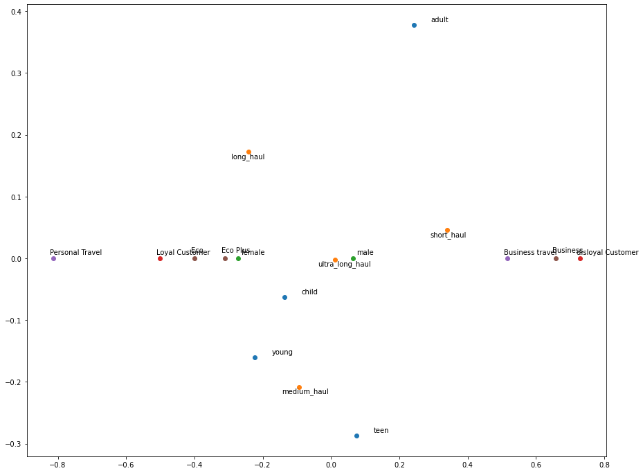

```python
fig = matplotlib.pyplot.gcf()
fig.set_size_inches(15, 12)


age_x = df_weights['Age_c_int_embed'].to_numpy()[0][:,0]
age_y = df_weights['Age_c_int_embed'].to_numpy()[0][:,1]
age_l = age_map

plt.scatter(age_x, age_y)
for i, txt in enumerate(age_l):
    plt.annotate(txt, (age_x[i], age_y[i]), textcoords='data', xytext=(age_x[i] +.05, age_y[i] +.005 ))


flight_x = df_weights['Flight_Distance_c_int_embed'].to_numpy()[0][:,0]
flight_y = df_weights['Flight_Distance_c_int_embed'].to_numpy()[0][:,1]
flight_l = flight_distance_map

plt.scatter(flight_x, flight_y)
for i, txt in enumerate(flight_l):
    plt.annotate(txt, (flight_x[i], flight_y[i]), textcoords='data' , xytext=(flight_x[i] -.05, flight_y[i] -.01 ))


gender_x = df_weights['Gender_int_embed'].to_numpy()[0]
gender_l = gender_map

plt.scatter(gender_x, [0,0])
for i, txt in enumerate(gender_l):
    plt.annotate(txt, (gender_x[i], 0) , xytext=(gender_x[i] +.01, .006 ))


cust_x = df_weights['Customer_Type_int_embed'].to_numpy()[0]
cust_l = cutomer_type_map

plt.scatter(cust_x, [0,0])
for i, txt in enumerate(cust_l):
    plt.annotate(txt, (cust_x[i], 0), xytext=(cust_x[i] -.01, .006 ))


type_travel_x = df_weights['Type_of_Travel_int_embed'].to_numpy()[0]
type_travel_l = type_of_travel_map

plt.scatter(type_travel_x, [0,0])
for i, txt in enumerate(type_travel_l):
    plt.annotate(txt, (type_travel_x[i], 0) , xytext=(type_travel_x[i] -.01, .006 ))


class_x = df_weights['Class_int_embed'].to_numpy()[0]
class_l = class_map

plt.scatter(class_x, [0,0,0])
for i, txt in enumerate(class_l):
    plt.annotate(txt, (class_x[i], 0) , xytext=(class_x[i] -.01, .01 ))


plt.show()
```

We show all look-up tables in one plot to demonstrate other attributes that we did not discuss above.

The plot could be more meaningful if the dataset has more classes in categorical attributes. It is also possible to create one categorical feature that contains all classes and pass it to one embedded layer and apply the dimension reduction technique to plot it and find the relationship between classes. Our networks are not created with that approach, so we used one of our models to store the embeddings.

### References:

[1] https://www.theacsi.org/industries/travel/airline

[2] https://www.jdpower.com/business/press-releases/2020-north-america-airline-satisfaction-study

[3] Airline Passenger Satisfaction dataset https://www.kaggle.com/teejmahal20/airline-passenger-satisfaction

[4] Filipe R. Lucini, Leandro M. Tonetto, Flavio S. Fogliatto, Michel J. Anzanello, Text mining approach to explore dimensions of airline customer satisfaction using online customer reviews, Journal of Air Transport Management, Volume 83, 2020, 101760, ISSN 0969-6997, https://doi.org/10.1016/j.jairtraman.2019.101760. (https://www.sciencedirect.com/science/article/pii/S0969699719302959)

[5] https://www.pointhacks.com.au/differences-short-medium-long-haul-flights/